# BellaBeat_analysis

Jamin

2025-08-19

# About the Company-

### Bellabeat, a hightech company that manufactures health-focused smart products. since founded in 2013, Bellabeat has grown rapidly and quickly positioned itself as a tech-driven wellness company for women. By 2016, Bellabeat had opened offices around the world and launched multiple products. Srsen, president, knows that an analysis of Bellabeats available consumer data would reveal more opportunities for growth and needs our help to find patterns to make recommendations and inform the marketing team.

# ASK

### Questions we will be tasked with during our anlaysis.

- 1. What are some trends in smart device usage?
- 2. How could these trends apply to Bellabeat customers?
- 3. How could these trends help influence Bellabeat marketing strategy?

# Business Task

#### Identify potential opportunities for business growth based on customer interaction with products. Giving recommendations of where to focus our efforts in reaching new customers and challenging current customers.

## Loading packages needed for Analysis

```r
#install-'tidyverse package if not done so.
library(tidyverse) # this loads ggplots, dplyr, lubridate, ect.
library(ggplot2)
library(dplyr)
library(lubridate)
library(tidyr)
library(readr)
library(hms)
library(scales)
```

#### Downloaded all google sheets and converted them into CSV files. Now ready to load into R using read_csv. Make sure “/” is used to recognize file path in Rstudio. We also provided dataframe names using the “<-”

```r
activity <- read_csv("C:/Users/jmcla/OneDrive/Documents/DATA Analytics/Portfolio_CaseStudy/Case_study_samples/Fit Bit case study2/Fitabase Data 3.12.16-4.11.16/dailyActivity_merged.csv", col_types=cols(.default="c"))

calories <- read_csv("C:/Users/jmcla/OneDrive/Documents/DATA Analytics/Portfolio_CaseStudy/Case_study_samples/Fit Bit case study2/Fitabase Data 3.12.16-4.11.16/hourlyCalories_merged.csv", col_types=cols(.default="c"))


sleep <- read_csv("C:/Users/jmcla/OneDrive/Documents/DATA Analytics/Portfolio_CaseStudy/Case_study_samples/Fit Bit case study2/Fitabase Data 3.12.16-4.11.16/minuteSleep_merged.csv",col_types=cols(.default="c"))


weight <- read_csv("C:/Users/jmcla/OneDrive/Documents/DATA Analytics/Portfolio_CaseStudy/Case_study_samples/Fit Bit case study2/Fitabase Data 3.12.16-4.11.16/weightLogInfo_merged.csv", col_types=cols(.default="c"))


intensities <- read_csv ("C:/Users/jmcla/OneDrive/Documents/DATA Analytics/Portfolio_CaseStudy/Case_study_samples/Fit Bit case study2/Fitabase Data 3.12.16-4.11.16/hourlyIntensities_merged.csv", col_types=cols(.default="c"))

steps <- read_csv ("C:/Users/jmcla/OneDrive/Documents/DATA Analytics/Portfolio_CaseStudy/Case_study_samples/Fit Bit case study2/Fitabase Data 3.12.16-4.11.16/hourlySteps_merged.csv", col_types=cols(.default="c"))

heartRate <- read_csv ("C:/Users/jmcla/OneDrive/Documents/DATA Analytics/Portfolio_CaseStudy/Case_study_samples/Fit Bit case study2/Fitabase Data 3.12.16-4.11.16/heartrate_seconds_merged.csv", col_types=cols(.default="c"))
```

#### checking the column and table layout to verify our data and format.

```r
head(sleep)
```

| Id | date | value | logId |
| --- | --- | --- | --- |
| 1503960366 | 3/13/2016 2:39:30 AM | 1 | 11114919637 |
| 1503960366 | 3/13/2016 2:40:30 AM | 1 | 11114919637 |
| 1503960366 | 3/13/2016 2:41:30 AM | 1 | 11114919637 |
| 1503960366 | 3/13/2016 2:42:30 AM | 1 | 11114919637 |
| 1503960366 | 3/13/2016 2:43:30 AM | 1 | 11114919637 |
| 1503960366 | 3/13/2016 2:44:30 AM | 1 | 11114919637 |

```r
colnames(sleep)
```

```
## [1] "Id"    "date"  "value" "logId"
```

#### The ActivityHour columns in multiple sheets share date & Time together in the same column. we will need to separate using the lubridate() within Tidyverse package.

#### First, will run a class function to recognize that each of our data frames are recognized and not considered vector’s, which would produce errors in our lubridate ().

```r
class(activity)
```

```
## [1] "spec_tbl_df" "tbl_df"      "tbl"         "data.frame"
```

```r
class(sleep)
```

```
## [1] "spec_tbl_df" "tbl_df"      "tbl"         "data.frame"
```

```r
class(intensities)
```

```
## [1] "spec_tbl_df" "tbl_df"      "tbl"         "data.frame"
```

```r
class(calories)
```

```
## [1] "spec_tbl_df" "tbl_df"      "tbl"         "data.frame"
```

```r
class(weight)
```

```
## [1] "spec_tbl_df" "tbl_df"      "tbl"         "data.frame"
```

#### now that class() verified our data frames, we can use lubridate to separate our columns we need the library(hms)function to properly separate our columns as characters and recognized as DateTime

#### pay close attention to our columns as some sheets have different column headers listed.

#### following code will separate columns and format data correctly. a pipe makes this easy.converts string to datetime (04/12/2016 09:14:00), extracts date, Extracts just the time

#### run a Head code to verify format of calories->ActivityHour column to give us proper MDY reading.

```r
head(calories$ActivityHour,5)
```

```
## [1] "3/12/2016 12:00:00 AM" "3/12/2016 1:00:00 AM"  "3/12/2016 2:00:00 AM"
## [4] "3/12/2016 3:00:00 AM"  "3/12/2016 4:00:00 AM"
```

```r
calories <- calories %>%
  mutate(ActivityHour = parse_date_time(ActivityHour, orders="mdy IMS p"),
          date=date(ActivityHour),
          time=as_hms(ActivityHour),
          ActivityDate=as.Date(ActivityHour))
```

```r
print(calories)
```

```
## # A tibble: 24,084 × 6
##    Id         ActivityHour        Calories date       time   ActivityDate
##    <chr>      <dttm>              <chr>    <date>     <time> <date>
##  1 1503960366 2016-03-12 00:00:00 48       2016-03-12 00:00  2016-03-12
##  2 1503960366 2016-03-12 01:00:00 48       2016-03-12 01:00  2016-03-12
##  3 1503960366 2016-03-12 02:00:00 48       2016-03-12 02:00  2016-03-12
##  4 1503960366 2016-03-12 03:00:00 48       2016-03-12 03:00  2016-03-12
##  5 1503960366 2016-03-12 04:00:00 48       2016-03-12 04:00  2016-03-12
##  6 1503960366 2016-03-12 05:00:00 48       2016-03-12 05:00  2016-03-12
##  7 1503960366 2016-03-12 06:00:00 48       2016-03-12 06:00  2016-03-12
##  8 1503960366 2016-03-12 07:00:00 48       2016-03-12 07:00  2016-03-12
##  9 1503960366 2016-03-12 08:00:00 48       2016-03-12 08:00  2016-03-12
## 10 1503960366 2016-03-12 09:00:00 49       2016-03-12 09:00  2016-03-12
## # ℹ 24,074 more rows
```

#### Repeat for the following sheets that need conversion for both date/time and making values numeric to allow our plot to be readable.

```r
activity<- activity %>%
  mutate(SedentaryMinutes=as.numeric(SedentaryMinutes),
         TotalSteps=as.numeric(TotalSteps),
         Calories=as.numeric(Calories),
         LightlyActiveMinutes= as.numeric(LightlyActiveMinutes),
         FairlyActiveMinutes=as.numeric(FairlyActiveMinutes),
         VeryActiveMinutes=as.numeric(VeryActiveMinutes))
```

```r
sleep <- sleep %>%

  mutate(ActivityTime=mdy_hms(date), date=date(ActivityTime), time=as_hms(ActivityTime))
View(sleep)
```

```r
intensities<-intensities%>%
  mutate(ActivityHour = mdy_hms(ActivityHour),
         date=date(ActivityHour),
         time=as_hms(ActivityHour))
```

```r
weight<-weight %>%
  mutate(ActivityTime=mdy_hms(Date)
         ) %>% #create datetime column to have R recognize ActivityTime before using it.
  mutate(date=date(ActivityTime), time=as_hms(ActivityTime))
```

```r
steps<-steps %>%
  mutate(ActivityHour=mdy_hms(ActivityHour), date=date(ActivityHour), time=as_hms(ActivityHour))
heartRate<-heartRate %>%
  mutate(Time=mdy_hms(Time), date=date(Time), time=as_hms(Time))
```

#### How many unique participants are there in each dataframe

```r
n_distinct(activity$Id)
```

```
## [1] 35
```

```r
n_distinct(steps$Id)
```

```
## [1] 34
```

```r
n_distinct(sleep$Id)
```

```
## [1] 23
```

```r
n_distinct(calories$Id)
```

```
## [1] 34
```

```r
n_distinct(weight$Id)
```

```
## [1] 11
```

```r
n_distinct(intensities$Id)
```

```
## [1] 34
```

```r
n_distinct(heartRate$Id)
```

```
## [1] 14
```

#### Results indicate that 11ppl participated in weights data frame and 14ppl in the heartRate, which could result in survey bias. How many observations are in each data frame.

```r
nrow(activity)
```

```
## [1] 457
```

```r
nrow(sleep)
```

```
## [1] 198559
```

```r
nrow(weight)
```

```
## [1] 33
```

```r
nrow(steps)
```

```
## [1] 24084
```

```r
nrow(calories)
```

```
## [1] 24084
```

```r
nrow(intensities)
```

```
## [1] 24084
```

```r
nrow(heartRate)
```

```
## [1] 1154681
```

#### Again, weight data frame has a significant difference in entries. Therefore, we will conclude this data to be irrelevantl and Bias.

#### The Activity dataframe also has low amount of entries compared to the others but lets keep it in mind for our analysis as it does have 35 participants.

#### lets run a summary table of our data frames to get a clearer picture of our data.

```r
activity%>%
  select(TotalSteps,TotalDistance,Calories,SedentaryMinutes)%>%
  summary()
```

```
##    TotalSteps    TotalDistance         Calories    SedentaryMinutes
##  Min.   :    0   Length:457         Min.   :   0   Min.   :  32.0
##  1st Qu.: 1988   Class :character   1st Qu.:1776   1st Qu.: 728.0
##  Median : 5986   Mode  :character   Median :2062   Median :1057.0
##  Mean   : 6547                      Mean   :2189   Mean   : 995.3
##  3rd Qu.:10198                      3rd Qu.:2667   3rd Qu.:1285.0
##  Max.   :28497                      Max.   :4562   Max.   :1440.0
```

```r
activity%>%
  select(VeryActiveMinutes,FairlyActiveMinutes,LightlyActiveMinutes) %>%
  summary()
```

```
##  VeryActiveMinutes FairlyActiveMinutes LightlyActiveMinutes
##  Min.   :  0.00    Min.   :  0.00      Min.   :  0.0
##  1st Qu.:  0.00    1st Qu.:  0.00      1st Qu.: 64.0
##  Median :  0.00    Median :  1.00      Median :181.0
##  Mean   : 16.62    Mean   : 13.07      Mean   :170.1
##  3rd Qu.: 25.00    3rd Qu.: 16.00      3rd Qu.:257.0
##  Max.   :202.00    Max.   :660.00      Max.   :720.0
```

```r
intensities%>%
  select(ActivityHour, TotalIntensity, AverageIntensity)%>%
  summary()
```

```
##   ActivityHour                 TotalIntensity     AverageIntensity
##  Min.   :2016-03-12 00:00:00   Length:24084       Length:24084
##  1st Qu.:2016-03-19 14:00:00   Class :character   Class :character
##  Median :2016-03-27 04:00:00   Mode  :character   Mode  :character
##  Mean   :2016-03-27 05:47:23
##  3rd Qu.:2016-04-03 20:00:00
##  Max.   :2016-04-12 10:00:00
```

```r
calories%>%
  select(ActivityHour,Calories)%>%
  summary()
```

```
##   ActivityHour                   Calories
##  Min.   :2016-03-12 00:00:00   Length:24084
##  1st Qu.:2016-03-19 14:00:00   Class :character
##  Median :2016-03-27 04:00:00   Mode  :character
##  Mean   :2016-03-27 05:47:23
##  3rd Qu.:2016-04-03 20:00:00
##  Max.   :2016-04-12 10:00:00
```

```r
steps%>%
  select(ActivityHour, StepTotal)%>%
  summary()
```

```
##   ActivityHour                  StepTotal
##  Min.   :2016-03-12 00:00:00   Length:24084
##  1st Qu.:2016-03-19 14:00:00   Class :character
##  Median :2016-03-27 04:00:00   Mode  :character
##  Mean   :2016-03-27 05:47:23
##  3rd Qu.:2016-04-03 20:00:00
##  Max.   :2016-04-12 10:00:00
```

```r
heartRate%>%
  select(Time,Value)%>%
  summary()
```

```
##       Time                        Value
##  Min.   :2016-03-29 00:00:05   Length:1154681
##  1st Qu.:2016-04-03 09:22:40   Class :character
##  Median :2016-04-06 03:55:07   Mode  :character
##  Mean   :2016-04-06 03:14:15
##  3rd Qu.:2016-04-08 19:16:45
##  Max.   :2016-04-12 11:03:15
```

```r
activity %>%
  summarize(avg_calories = mean(Calories, na.rm=TRUE),
            avg_steps = mean(TotalSteps, na.rm=TRUE))
```

| avg_calories | avg_steps |
| --- | --- |
| 2189.453 | 6546.562 |

## Summary and Key Points

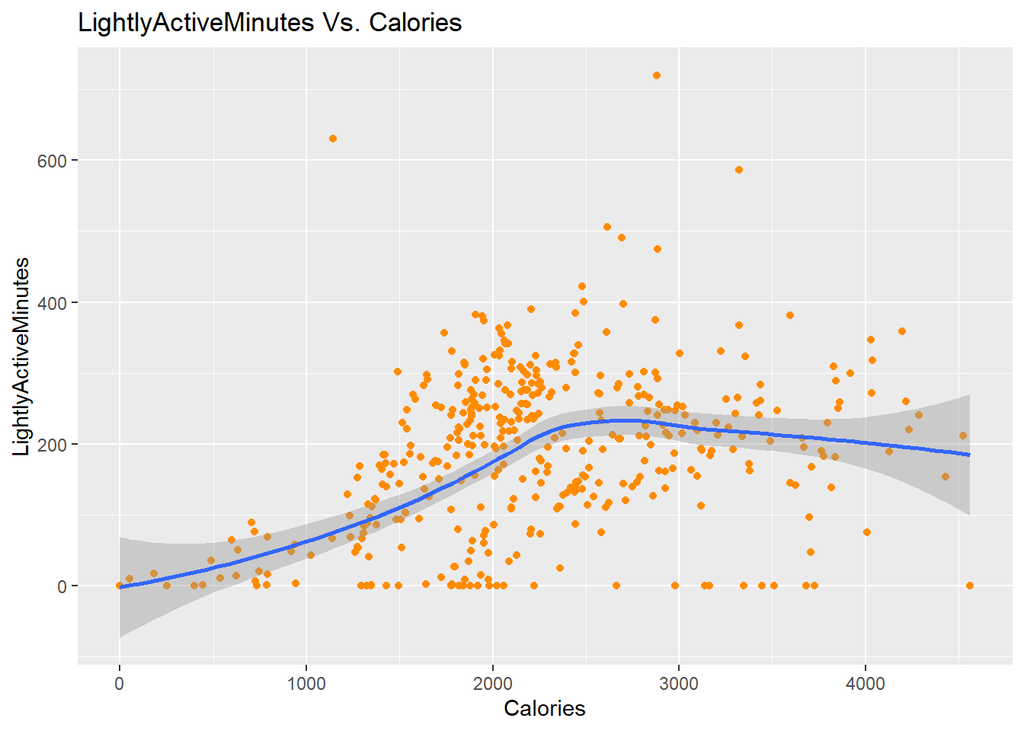

```r
activity_new2<- activity%>%
  group_by(Calories)%>%
  drop_na()%>%
  summarize(mean_total_Activity=mean(LightlyActiveMinutes))

ggplot(data=activity, aes(x= Calories, y= LightlyActiveMinutes))+
  geom_point(color='darkorange')+ geom_smooth()+
  labs(title='LightlyActiveMinutes Vs. Calories')
```

#### this gives us a good visual with the blue smooth line that identifes the trend in comparing calories and minutes active. Notice there are some anomolies which will happen in all datasets.

```r
# We will reformat both the activity and calorie dataframe for consistency.
activity<-activity%>%
  mutate(ActivityDate=as.Date(ActivityDate, format= "%m/%d/%Y"))%>%
  mutate(Id=as.character(Id))

# Need to convert the 'ActivityHour' column (date and time) into a proper Date object, and assign
# it to the new column name 'ActivityDate'. First coerce column to character, then POSIXct (date/time),
# and finally truncate the standard Date class.
calories<-calories %>%
 mutate(ActivityDate=as.Date(as.POSIXct(as.character(ActivityHour), format = "%m/%d/%Y %I:%M:%S %p"))) %>%
  mutate(Id=as.character(Id))

activity_calories<- activity %>%
    mutate(ActivityDate= as.Date(ActivityDate, format= "%m/%d/%Y")) # fixes datetime mismatch of column names
  activity_calories <- activity %>%
    left_join(calories, by= c("Id", "ActivityDate")) #performs a clean join
```

#### Now we will work on a new dataframe to combine types of data and then plot them to show calories verse Activities

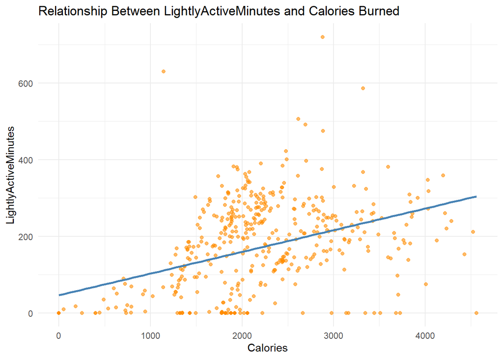

```r
ggplot(activity, aes(x=Calories, y=LightlyActiveMinutes)) +
  geom_point(color='darkorange', alpha=.6)+
  geom_smooth(method="lm", color="steelblue", se = FALSE)+
  labs( title= "Relationship Between LightlyActiveMinutes and Calories Burned",
        x="Calories", Y="Lightly Active Minutes")+
  theme_minimal()
```

#### Now we will separate by each activity type and color code them differently for a nice clean look.

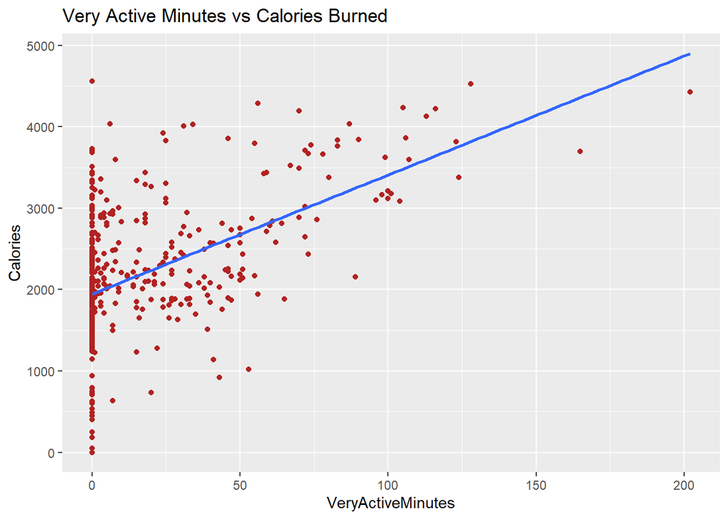

```r
ggplot(activity, aes(x= VeryActiveMinutes, y=Calories))+
  geom_point(color="firebrick")+
  geom_smooth(method= "lm", se= FALSE)+
  labs(title= "Very Active Minutes vs Calories Burned")
```

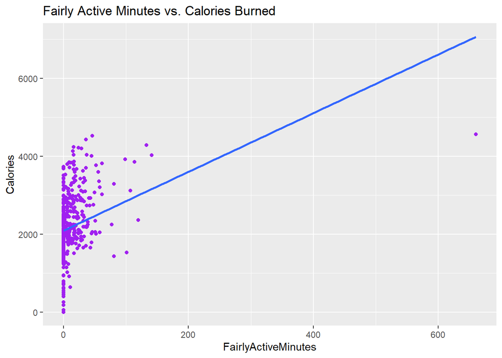

```r
ggplot(activity, aes(x=FairlyActiveMinutes, y=Calories))+
  geom_point(color="purple", alpha=500)+
  geom_smooth(method="lm", se=FALSE)+
  labs(title="Fairly Active Minutes vs. Calories Burned")
```

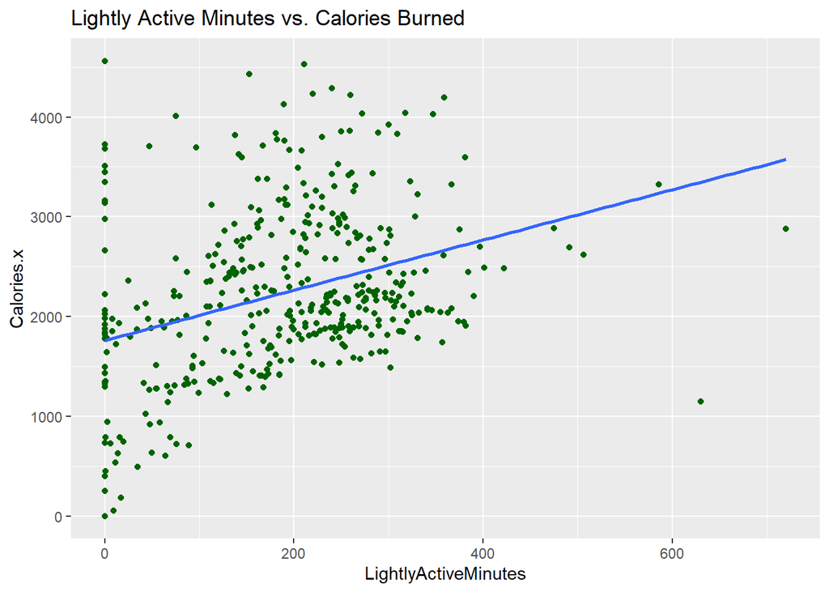

```r
ggplot(activity_calories, aes(x=LightlyActiveMinutes, y=Calories.x))+
         geom_point(color="darkgreen")+
         geom_smooth(method= "lm", se= FALSE)+
         labs(title="Lightly Active Minutes vs. Calories Burned")
```

```r
#Finally, lets compare each activity type side-by-side. we will use the Pivot Long function to support this data frame.
```

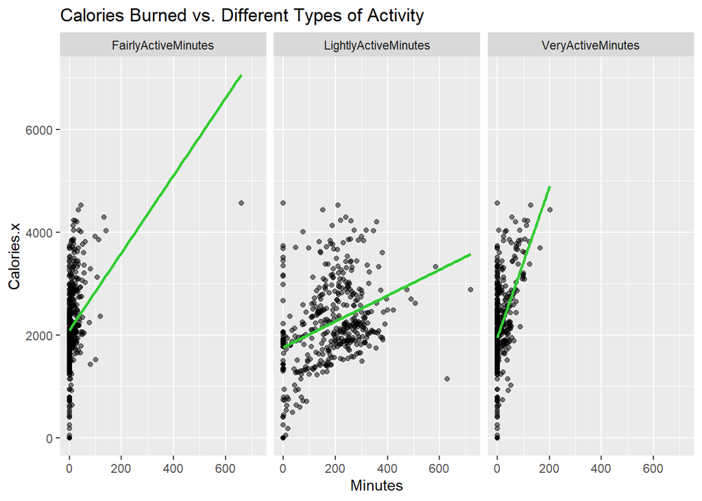

```r
activity_calories<- activity_calories %>%
  mutate(LightlyActiveMinutes= as.numeric(LightlyActiveMinutes),
         FairlyActiveMinutes = as.numeric(FairlyActiveMinutes),
         VeryActiveMinutes = as.numeric(VeryActiveMinutes))


activity_long<- activity_calories%>%
  pivot_longer(cols=c(LightlyActiveMinutes, FairlyActiveMinutes,VeryActiveMinutes),
               names_to= "ActivityType",
               values_to="Minutes")
ggplot(activity_long, aes(x= Minutes, y=Calories.x))+
  geom_point(alpha=0.5)+
  geom_smooth(method="lm", se= FALSE, color="limegreen")+
  facet_wrap(~ActivityType)+
  labs(title="Calories Burned vs. Different Types of Activity")
```

#### Lets track to see where most activity Levels are according to the days of the week

#### First we will remove all non-date characters and convert to Date object. Then ensure our data on the Y-variable is numeric in order to read properly. Wday(label=TRUE) ensures correct ordering for the x-axis. Last, our diagnostic check is good verification that our weekdays found reads “7”

```r
activity <- read_csv("C:/Users/jmcla/OneDrive/Documents/DATA Analytics/Portfolio_CaseStudy/Case_study_samples/Fit Bit case study2/Fitabase Data 3.12.16-4.11.16/dailyActivity_merged.csv", col_types=cols(.default="c"))

cleaned_dates <- gsub(pattern = "[^0-9/]", replacement = "", x = activity$ActivityDate)
activity$ActivityDate <- mdy(cleaned_dates)

print(paste("TotalSteps class before conversion:", class(activity$TotalSteps)))
```

```
## [1] "TotalSteps class before conversion: character"
```

```r
activity$TotalSteps <- as.numeric(activity$TotalSteps)
print(paste("TotalSteps class after conversion:", class(activity$TotalSteps)))
```

```
## [1] "TotalSteps class after conversion: numeric"
```

```r
activity$weekday <- wday(activity$ActivityDate, label = TRUE)

print(paste("Number of unique weekdays found:", length(unique(activity$weekday))))
```

```
## [1] "Number of unique weekdays found: 7"
```

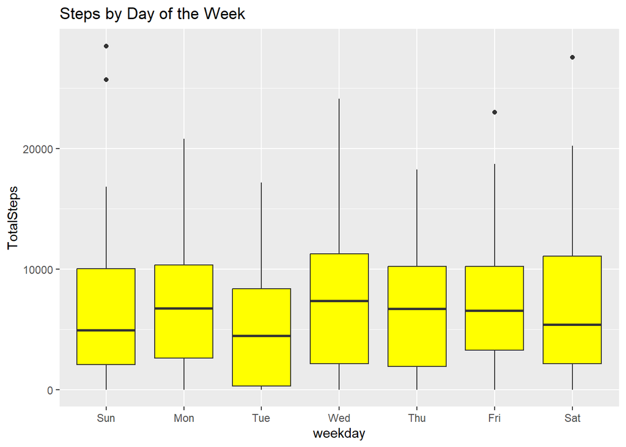

```r
ggplot(activity, aes(x=weekday, y=TotalSteps)) +
  geom_boxplot(fill="yellow") +
  labs(title="Steps by Day of the Week")
```

## Top 5 users from our analysis and show total steps and calories.

```r
activity %>% mutate(Calories=as.numeric(Calories))%>%
  group_by(Id) %>%
  summarize(TotalSteps = sum(TotalSteps, na.rm=TRUE),
            TotalCalories = sum(Calories, na.rm=TRUE)) %>%
  arrange(desc(TotalSteps)) %>%
  head(5)
```

| Id | TotalSteps | TotalCalories |
| --- | --- | --- |
| 1503960366 | 221170 | 34128 |
| 8877689391 | 209005 | 41414 |
| 4020332650 | 184851 | 98412 |
| 6962181067 | 176956 | 29249 |
| 8053475328 | 163288 | 31825 |

# Conclusions

- Although HeartRate and Sleep had the most entries; the Steps, calories and activity sections had a higher amount of participants indicating a stronger usage in these categories.
- Light Activity produced had the highest mean compared to FairlyActive and VeryActive. This could be because of their individual profession where they spend most of their time.
- Data also shows a high amount of SedentaryMinutes with avg. 995 which means most participants were active only 31% of their day.
- 24hrs a day x 60minutes in an hour = 1440 minutes. 995min/1440Min = .69. 1-.69=.31
- utilize the sedetary minutes block to release “targeted campaings/promotions” while you have the users attention.
- Bellabeat has incurred a fast growth rate and has appealed to several women across the globe.